# NYPD Shooting Incident Analysis

Denzil James Greenwood

June 24 2024

```r
# This section loads the required libraries for the analysis
knitr::opts_chunk$set(echo = TRUE, tidy.opts = list(width.cutoff = 80), tidy = TRUE)

# Function to check and install missing packages
check_and_install <- function(package) {
  if (!requireNamespace(package, quietly = TRUE)) {
    install.packages(package, dependencies = TRUE)
  }
  library(package, character.only = TRUE)
}

# List of required packages
required_packages <- c(
  "caret", "cluster", "dplyr", "forcats", "ggplot2","ggthemes",
  "glmnet", "gridExtra", "htmltools", "kableExtra", "knitr",
  "leaflet", "lubridate", "purrr", "pROC", "RColorBrewer",
  "readr", "rmarkdown", "ROCR", "sf", "stringr", "tidyverse",
  "tinytex", "viridisLite", "webshot2"
  )


# Check and install missing packages
invisible(lapply(required_packages, check_and_install))
```

### Introduction and Background

Analyzing NYPD shooting incidents is crucial for understanding crime patterns and informing public safety strategies. This analysis can provide actionable insights to law enforcement and policymakers to address crime hot spots, allocate resources effectively, and develop targeted interventions to reduce gun violence.

### Objective of the Analysis

Our analysis aims to evaluate the usefulness of the NYPD shooting incident data since 2006 and to provide actionable insights and recommendations for improving this process in the future.

### NYPD Shooting Incident Data (Historic)

#### Metadata Updated: April 26, 2024

This dataset contains records of every shooting incident that occurred in NYC from 2006 through the end of the previous calendar year. The data is manually extracted quarterly and reviewed by the Office of Management Analysis and Planning before being posted on the NYPD website. Each record includes information about the event, location, time of occurrence, and suspect and victim demographics. This dataset can be used by the public to explore the nature of shooting/criminal activity.

Source: NYPD Shooting Incident Data (Historic) https://catalog.data.gov/dataset/nypd-shooting-incident-data-historic

```r
# Load the NYPD Shooting Incident data from the URL creates global variables
# for the data and column names

url_in = "https://data.cityofnewyork.us/api/views/833y-fsy8/rows.csv?accessType=DOWNLOAD"
NYPD_data = read_csv(url_in)


# Add global variables List of columns to analyze
COLUMNS_TO_ANALYZE <- c("LOC_CLASSFCTN_DESC", "LOC_OF_OCCUR_DESC", "LOCATION_DESC",
    "PERP_AGE_GROUP", "PERP_SEX", "PERP_RACE", "VIC_AGE_GROUP", "VIC_SEX", "VIC_RACE")

# list of column names to be displayed in the title
COLUMN_NAMES <- c("Classification Description", "Location of occurrence description",
    "Location Description", "Perpetrator by Age Group", "Perpetrator by Sex", "Perpetrator by Racial Group",
    "Victim by Age Group", "Victim by Sex", "Victim by Racial Group")
```

#### NYPD Shooting Incident Data Sample

The following is the first ten lines of the NYPD Shooting Incident dataset (limited to the first five columns).

- We will download the information from the website here: https://data.cityofnewyork.us/Public-Safety/NYPD-Shooting-Incident-Data-Historic-/833y-fsy8/about_data.

```r
# This section displays the first 10 lines of the NYPD Shooting Incident data
# set
NYPD_data_head <- head(NYPD_data, 10)
NYPD_data_head <- NYPD_data_head[, 1:5]

# Create the HTML table
kable(NYPD_data_head, caption = "Displaying the first ten lines and five columns of the data. ") %>%
    kable_styling(bootstrap_options = c("striped", "hover", "condensed", "responsive")) %>%
    scroll_box(height = "450px", width = "100%") %>%
    add_header_above(c(` ` = 1, `NYPD Data` = ncol(NYPD_data_head) - 1))
```

Displaying the first ten lines and five columns of the data.

| INCIDENT_KEY | NYPD Data OCCUR_DATE | NYPD Data OCCUR_TIME | NYPD Data BORO | NYPD Data LOC_OF_OCCUR_DESC |
| --- | --- | --- | --- | --- |
| 244608249 | 05/05/2022 | 00:10:00 | MANHATTAN | INSIDE |
| 247542571 | 07/04/2022 | 22:20:00 | BRONX | OUTSIDE |
| 84967535 | 05/27/2012 | 19:35:00 | QUEENS | NA |
| 202853370 | 09/24/2019 | 21:00:00 | BRONX | NA |
| 27078636 | 02/25/2007 | 21:00:00 | BROOKLYN | NA |
| 230311078 | 07/01/2021 | 23:07:00 | MANHATTAN | NA |
| 229224142 | 06/07/2021 | 19:55:00 | QUEENS | NA |
| 231246224 | 07/22/2021 | 01:47:00 | BROOKLYN | NA |
| 228559720 | 05/22/2021 | 18:39:00 | BRONX | NA |
| 238210279 | 12/22/2021 | 23:17:00 | BRONX | NA |

### Column Names, Descriptions, Types of data and other related information:

NYPD Shooting Incident Level Data Footnotes

1. Information is accurate as of the date it was queried from the system of record, but should be considered a close approximation of current records, due to revisions and updates.
2. Data is available as of the date that technological enhancements to information systems allowed for data capture. Null values appearing frequently in certain fields may be attributed to changes on official department forms where data was previously not collected. Null values may also appear in instances where information was not available or unknown at the time of the report and should be considered as either “Unknown/Not Available/Not Reported.”
3. A shooting incident can have multiple victims involved and as a result duplicate INCIDENT_KEY’s are produced. Each INCIDENT_KEY represents a victim but similar duplicate keys are counted as one incident.
4. Shooting incidents occurring near an intersection are represented by the X coordinate and Y coordinates of the intersection Shooting incidents occurring anywhere other than at an intersection are geo-located to the middle of the nearest street segment where appropriate.
5. Any attempt to match the approximate location of the incident to an exact address or link to other datasets is not recommended.
6. Many other shooting incidents that were not able to be geo-coded (for example, due to an invalid address) have been located as occurring at the police station house within the precinct of occurrence.
7. Shooting incidents occurring in open areas such as parks or beaches may be geo-coded as occurring on streets or intersections bordering the area.
8. Shooting incidents occurring on a moving train on transit systems are geo-coded as occurring at the train’s next stop.
9. All shooting incidents occurring within the jurisdiction of the Department of Correction have been geo-coded as occurring on Riker’s Island.
10. X and Y Coordinates are in NAD 1983 State Plane New York Long Island Zone Feet (EPSG 2263).
11. Latitude and Longitude Coordinates are provided in Global Coordinate System WGS 1984 decimal degrees (EPSG 4326).
12. Errors in data transcription may result in nominal data inconsistencies.
13. The CSV file should be opened using an appropriate tool for data exploration, e.g. SPSS, SAS, Tableau, etc. If using MS Excel, be sure to use the tools for importing external data, otherwise inconsistencies may occur when viewing the data.
14. Only valid shooting incidents resulting in an injured victim are included in this release. Shooting incidents not resulting in an injured victim are classified according to the appropriate offense according to NYS Penal Law.
- Note: The previous information is provided from the following website. https://data.cityofnewyork.us/api/views/833y-fsy8/files/e4e3d86c-348f-4a16-a17f-19480c089429?download=true&filename=NYPD_Shootings_Incident_Level_Data_Footnotes.pdf
15. Field Names and Descriptions are as follows:

| Column Name | Description | Type |
| --- | --- | --- |
| INCIDENT_KEY | Randomly generated persistent ID for each arrest | Plain Text |
| OCCUR_DATE | Exact date of the shooting incident | Date & Time |
| OCCUR_TIME | Exact time of the shooting incident | Plain Text |
| BORO | Borough where the shooting incident occurred | Plain Text |
| LOC_OF_OCCUR_DESC | Description of the location of occurrence | Plain Text |
| PRECINCT | Precinct where the shooting incident occurred | Number |
| JURISDICTION_CODE | Jurisdiction where the shooting incident occurred. Jurisdiction codes 0(Patrol), 1(Transit), and 2(Housing) represent NYPD whilst codes 3 and more represent non-NYPD jurisdictions | Number |
| LOC_CLASSFCTN_DESC | Location classification description | Plain Text |
| LOCATION_DESC | Location of the shooting incident | Plain Text |
| STATISTICAL_MURDER_FLAG | Shooting resulted in the victim’s death which would be counted as a murder | Checkbox |
| PERP_AGE_GROUP | Perpetrator’s age within a category | Plain Text |
| PERP_SEX | Perpetrator’s sex description | Plain Text |
| PERP_RACE | Perpetrator’s race description | Plain Text |
| VIC_AGE_GROUP | Victim’s age within a category | Plain Text |
| VIC_SEX | Victim’s sex description | Plain Text |
| VIC_RACE | Victim’s race description | Plain Text |
| X_COORD_CD | Midblock X-coordinate for New York State Plane Coordinate System, Long Island Zone, NAD 83, units feet (FIPS 3104) | Plain Text |
| Y_COORD_CD | Midblock Y-coordinate for New York State Plane Coordinate System, Long Island Zone, NAD 83, units feet (FIPS 3104) | Plain Text |
| Latitude | Latitude coordinate for Global Coordinate System, WGS 1984, decimal degrees (EPSG 4326) | Number |
| Longitude | Longitude coordinate for Global Coordinate System, WGS 1984, decimal degrees (EPSG 4326) | Number |
| Lon_Lat | Longitude and Latitude Coordinates for mapping | Point |

- Note: The table name, description and data types are provided at the following website. https://data.cityofnewyork.us/Public-Safety/NYPD-Shooting-Incident-Data-Historic-/833y-fsy8/about_data.

### Summary Information by Column

Columns are analyzed in this section for NA and null values. The column names are unchanged from the original dataset, but the descriptions are provided in the title section as follows:

- LOC_CLASSFCTN_DESC: Classification of the location of the incident.
- LOCATION_DESC: Description of the location of the incident.
- PERP_AGE_GROUP: Age group of the perpetrator.
- PERP_SEX: Sex of the perpetrator (M-male/F-female/U-unknown).
- PERP_RACE: Perpetrator by racial group.
- VIC_AGE_GROUP: Age group of the victim.
- VIC_SEX: Sex of the victim (M-male/F-female/U-unknown).
- VIC_RACE: Victim by racial group.

#### Percentages of NA/Null Values for each column.

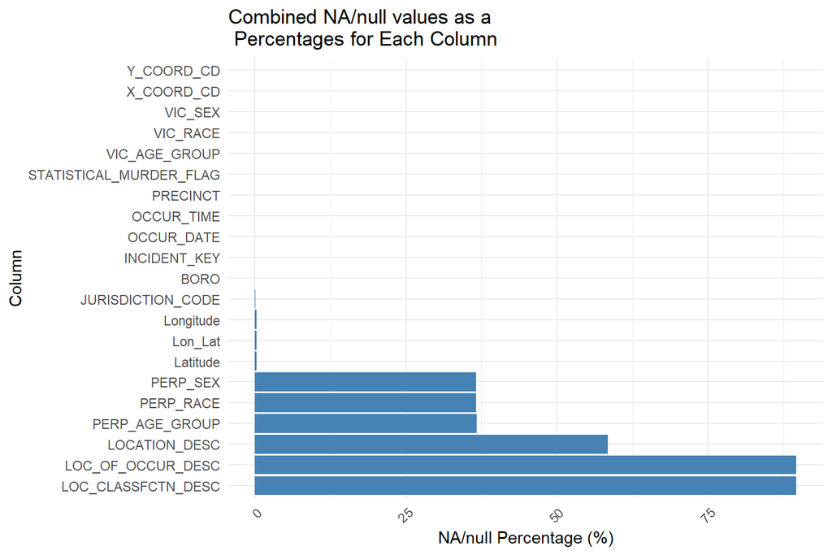

```r
# Define a function to calculate category counts and percentages for a given
# column
calculate_category_percentages <- function(data, column_name) {
    category_counts <- data %>%
        group_by(across(all_of(column_name))) %>%
        summarize(count = n(), .groups = "drop") %>%
        mutate(percentage = (count/nrow(data)) * 100)

    total_row <- data.frame(column_value = "Total", count = nrow(data), percentage = 100)
    colnames(total_row)[1] <- column_name

    bind_rows(category_counts, total_row)
}

# Define a function to calculate combined NA percentages for each column
calculate_combined_na_percentages <- function(data) {
    # Define a helper function to check for NA-like values
    is_na_like <- function(x) {
        is.na(x) | x %in% c("NA", "null", "NULL", "(null)", "")
    }

    # Calculate the percentage of combined NA-like values for each column
    na_percentages <- data %>%
        summarize(across(everything(), ~mean(is_na_like(.)) * 100)) %>%
        pivot_longer(cols = everything(), names_to = "Column", values_to = "NA_Percentage")

    na_percentages <- na_percentages %>%
        mutate(NA_Percentage = round(NA_Percentage, 2))

    na_percentages
}

# Apply the function to the data frame to calculate combined NA percentages
na_percentages <- calculate_combined_na_percentages(NYPD_data)

# Plot the NA percentages
na_percentages_plot <- na_percentages %>%
    ggplot(aes(x = reorder(Column, -NA_Percentage), y = NA_Percentage)) + geom_bar(stat = "identity",
    fill = "steelblue") + coord_flip() + labs(title = "Combined NA/null values as a\n Percentages for Each Column",
    x = "Column", y = "NA/null Percentage (%)") + theme_minimal() + theme(axis.text.x = element_text(angle = 45,
    hjust = 1))

# Print the plot
print(na_percentages_plot)
```

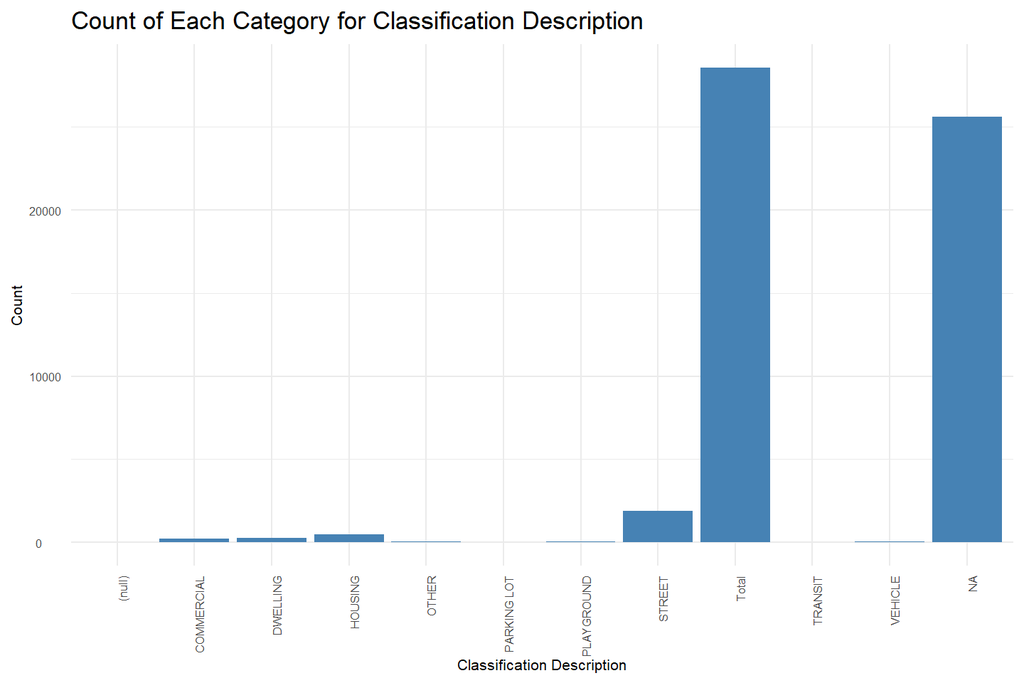

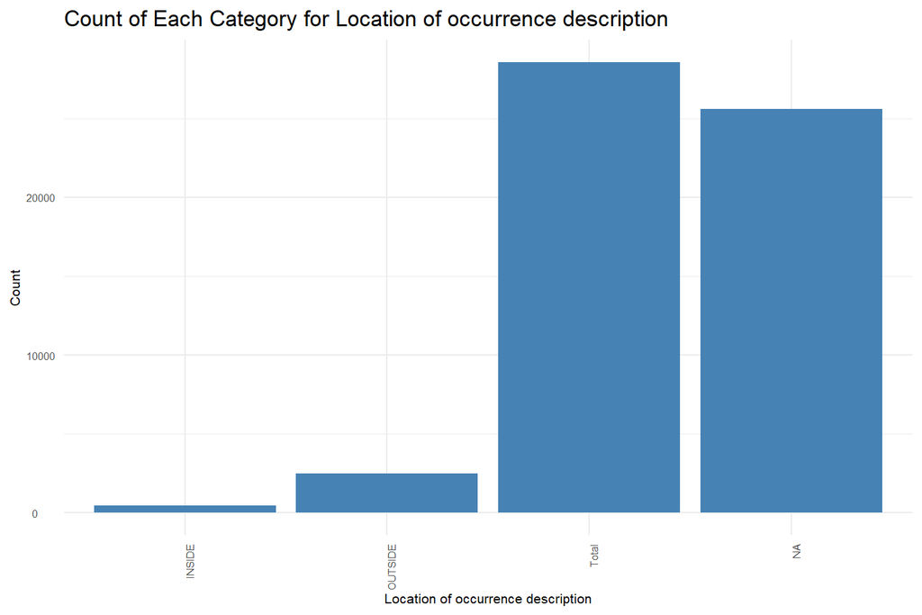

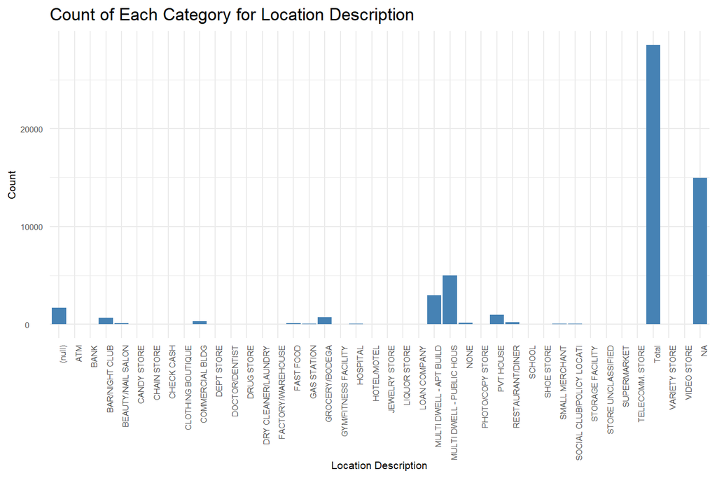

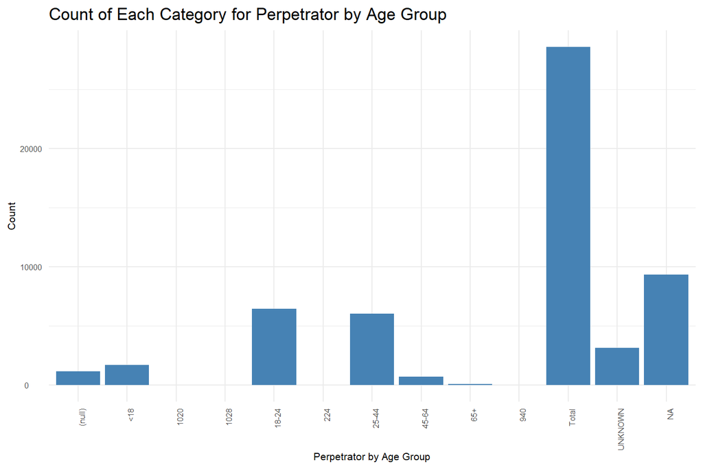

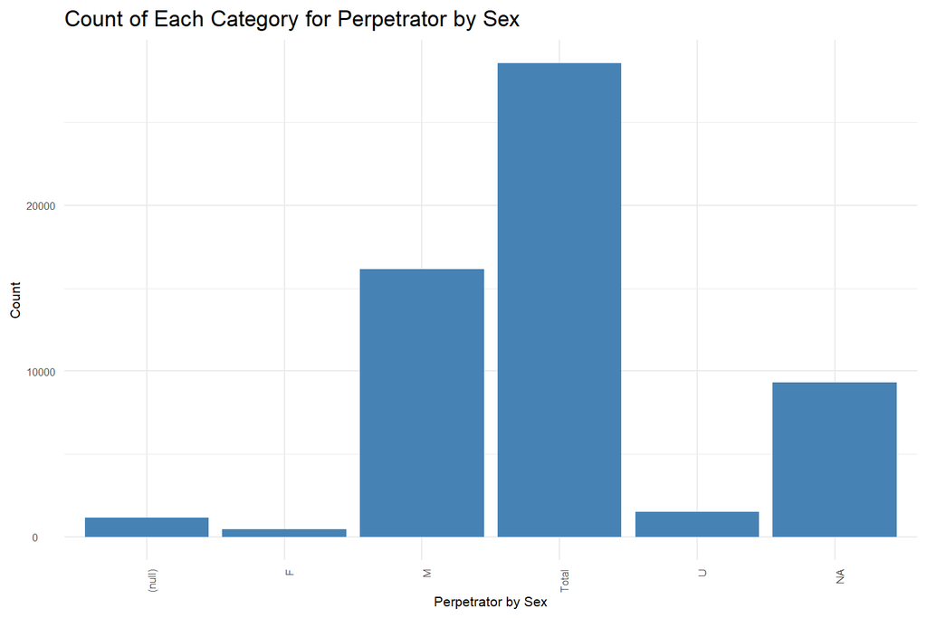

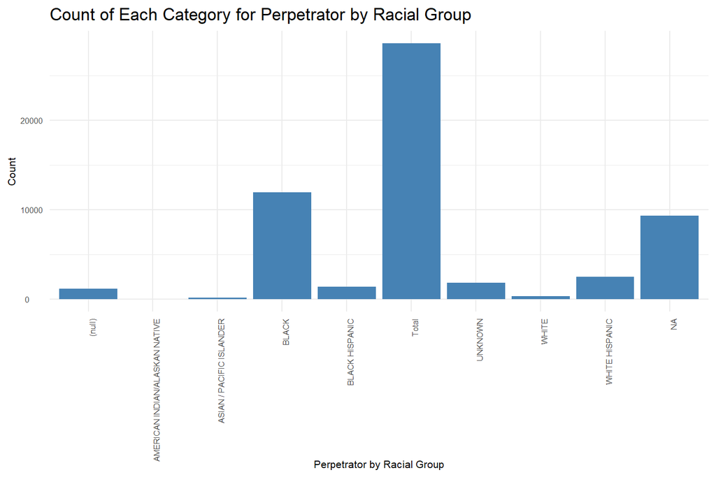

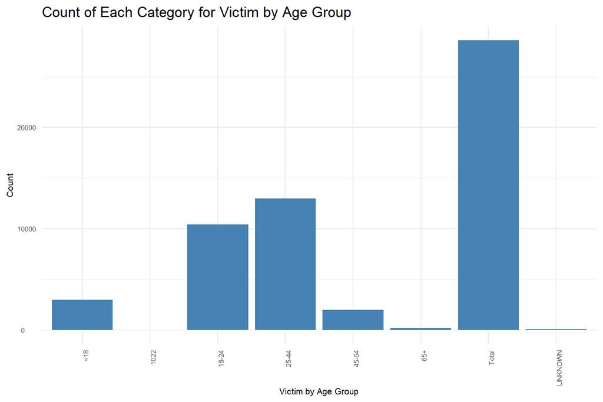

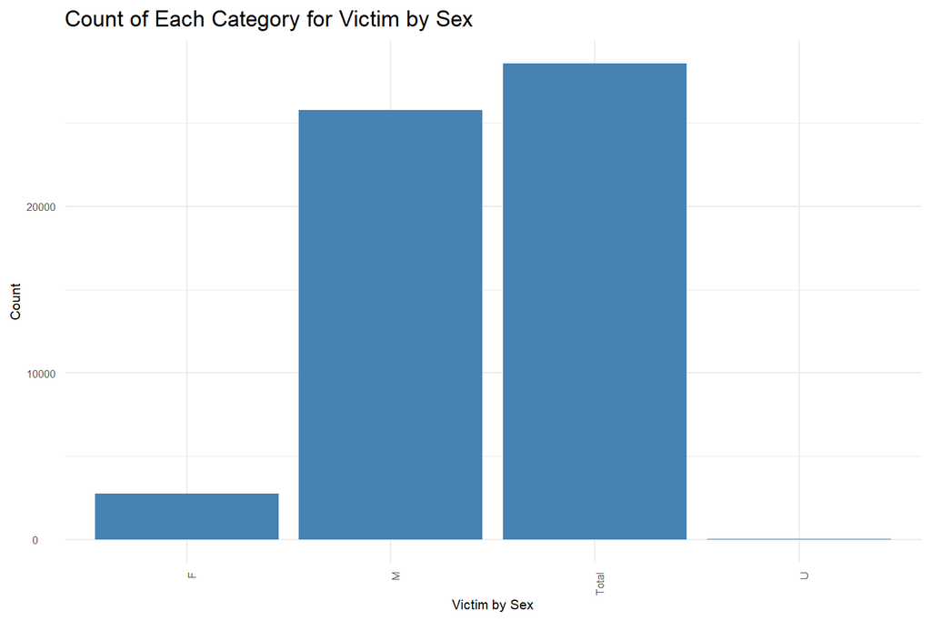

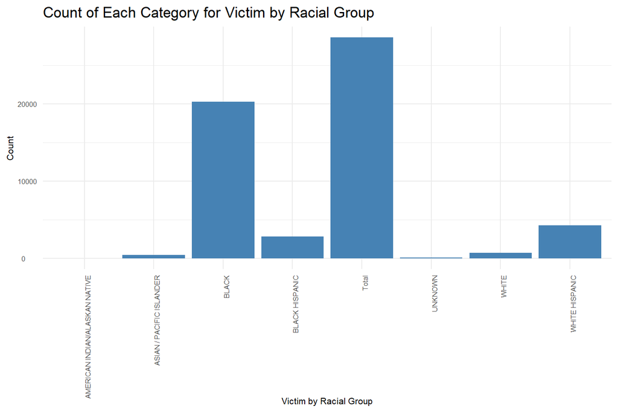

```r
# Create bar charts for each column
plot_list <- lapply(seq_along(COLUMNS_TO_ANALYZE), function(i) {
    col <- COLUMNS_TO_ANALYZE[i]
    col_name <- COLUMN_NAMES[i]

    category_percentages <- calculate_category_percentages(NYPD_data, col)

    ggplot(category_percentages, aes_string(x = col, y = "count")) + geom_bar(stat = "identity",
        fill = "steelblue") + labs(title = paste("Count of Each Category for", col_name),
        x = col_name, y = "Count") + theme_minimal() + theme(axis.title = element_text(size = 8),
        axis.text.y = element_text(size = 6, angle = 0, hjust = 0.25), axis.text.x = element_text(size = 6,
            angle = 90, hjust = 1))
})

# Print plots
for (plot in plot_list) {
    print(plot)
}
```

### Data Cleaning and Transformation

The following steps outline how the data is cleaned and transformed for analysis.

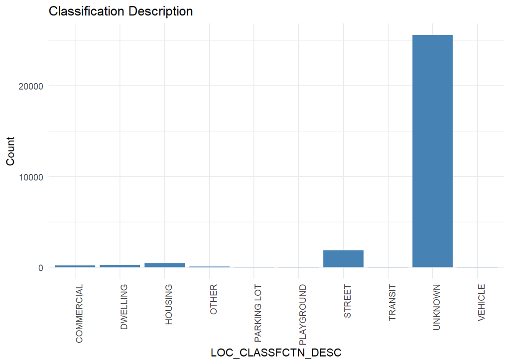

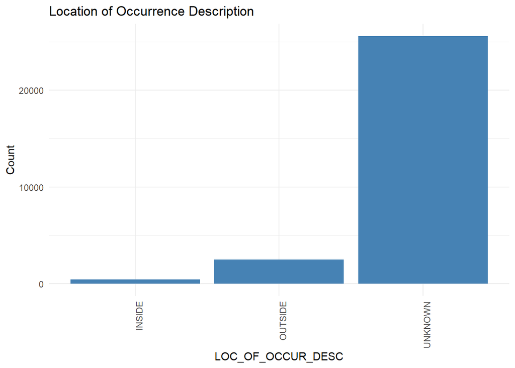

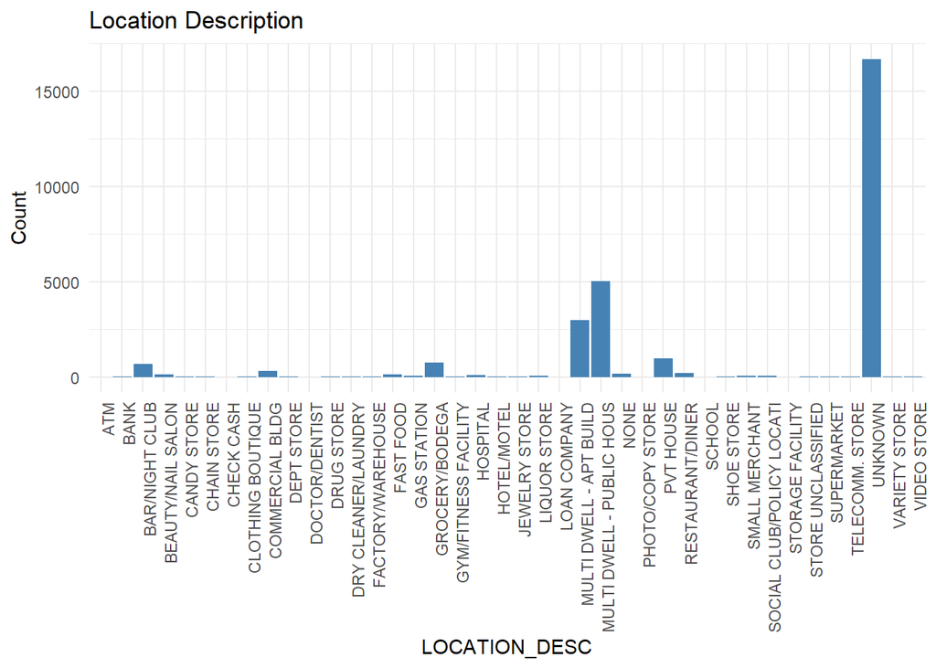

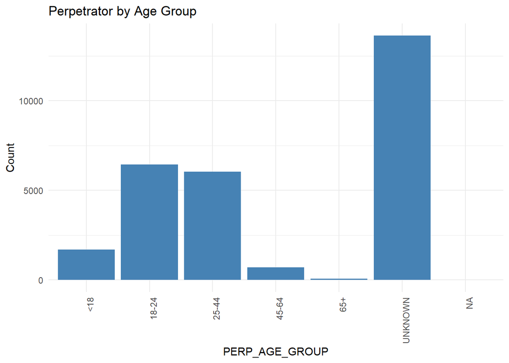

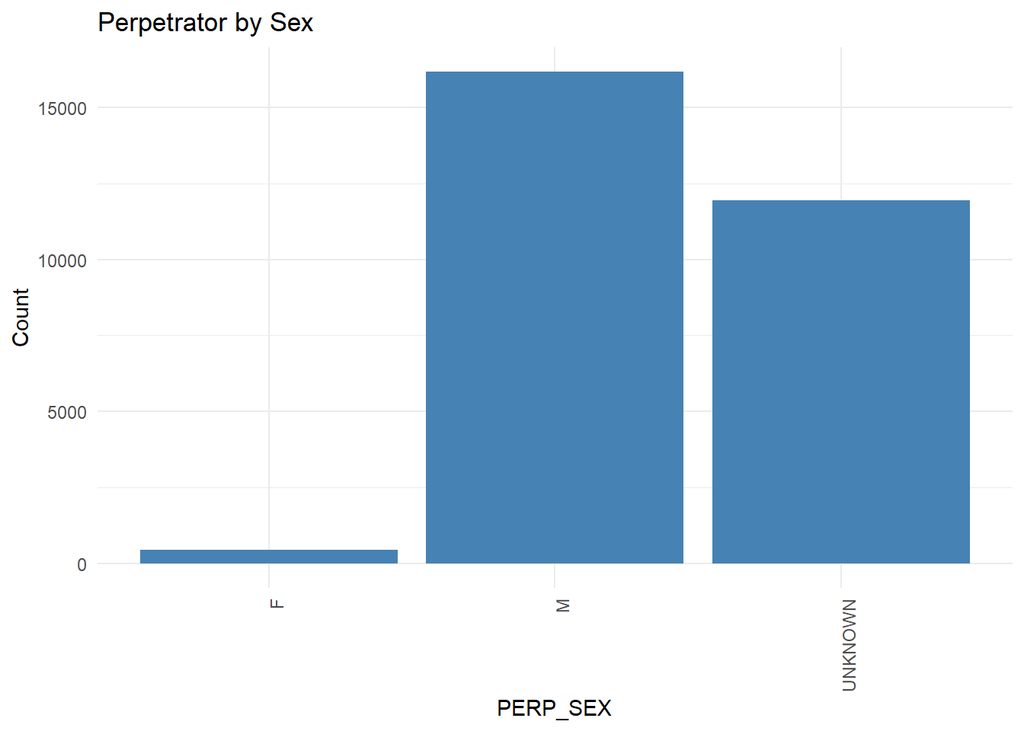

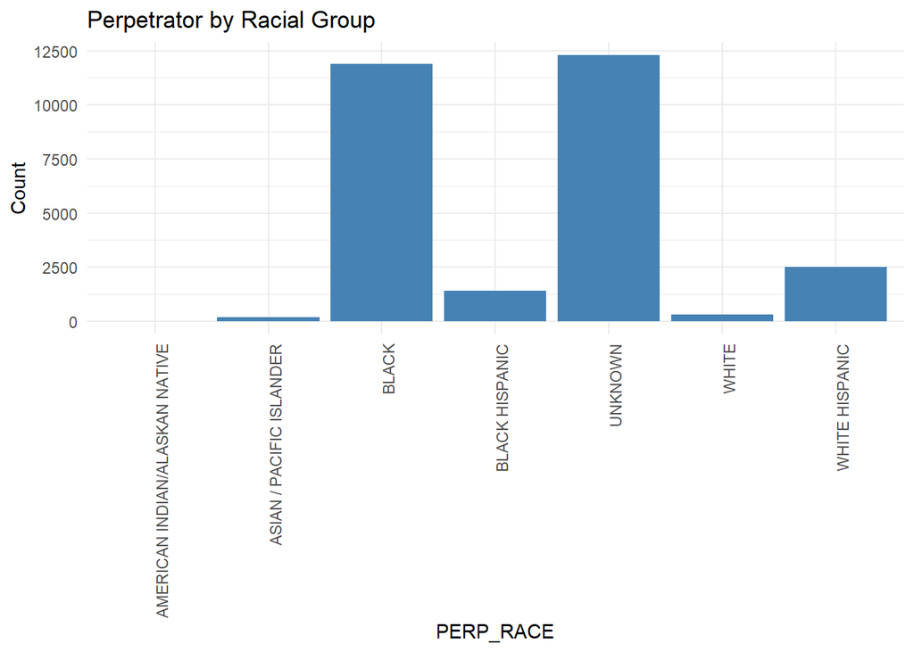

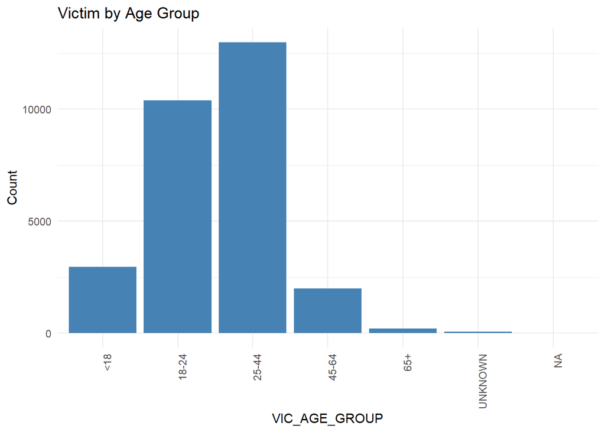

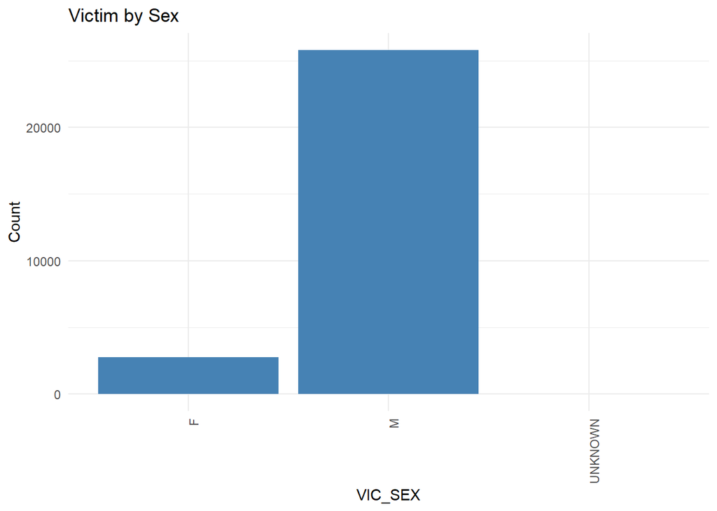

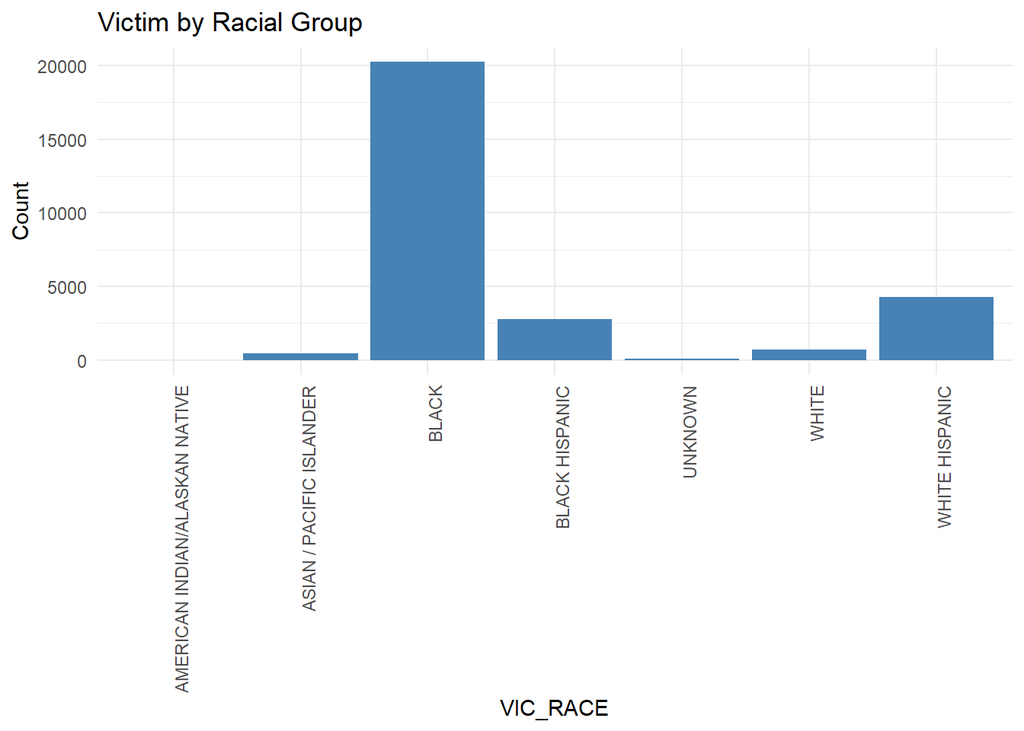

```r
# Clean the data by filling in missing values in LOC_CLASSFCTN_DESC,
# LOC_OF_OCCUR_DESC, and LOCATION_DESC
NYPD_data_cleaned <- NYPD_data

# Convert OCCUR_TIME to total seconds past midnight
NYPD_data_cleaned$OCCUR_TIME_SECONDS <- as.numeric(substr(NYPD_data_cleaned$OCCUR_TIME,
    1, 2)) * 3600 + as.numeric(substr(NYPD_data_cleaned$OCCUR_TIME, 4, 5)) * 60 +
    as.numeric(substr(NYPD_data_cleaned$OCCUR_TIME, 7, 8))

# Define a helper function to check for NA-like values
is_na_like <- function(x) {
    is.na(x) | x %in% c("na", "NA", "(null)", "null", "")
}

# Fill missing values in LOC_OF_OCCUR_DESC, LOC_CLASSFCTN_DESC, and
# LOCATION_DESC
NYPD_data_cleaned <- NYPD_data %>%
    mutate(LOC_CLASSFCTN_DESC = if_else(is_na_like(LOC_CLASSFCTN_DESC), "UNKNOWN",
        LOC_CLASSFCTN_DESC), LOC_OF_OCCUR_DESC = if_else(is_na_like(LOC_OF_OCCUR_DESC),
        "UNKNOWN", LOC_OF_OCCUR_DESC), LOCATION_DESC = if_else(is_na_like(LOCATION_DESC),
        "UNKNOWN", LOCATION_DESC))

# Convert PRECINCT and JURISDICTION_CODE to numeric
NYPD_data_cleaned <- NYPD_data_cleaned %>%
    mutate(PRECINCT = as.numeric(PRECINCT), JURISDICTION_CODE = as.numeric(JURISDICTION_CODE))

# Replace NA, 'na', and 'NULL' values with 'UNKNOWN' in PERP_SEX, VIC_SEX
# column
NYPD_data_cleaned <- NYPD_data_cleaned %>%
    mutate(PERP_SEX = case_when(is.na(PERP_SEX) ~ "UNKNOWN", PERP_SEX %in% c("na",
        "NA", "NULL", "(null)", "null", "U") ~ "UNKNOWN", TRUE ~ PERP_SEX), VIC_SEX = case_when(is.na(VIC_SEX) ~
        "UNKNOWN", VIC_SEX %in% c("na", "NA", "NULL", "(null)", "null", "U") ~ "UNKNOWN",
        TRUE ~ VIC_SEX))

# Replace NA, 'na', and 'NULL' values with 'UNKNOWN' in PERP_AGE_GROUP,
# VIC_AGE_GROUP columns
NYPD_data_cleaned <- NYPD_data_cleaned %>%
    mutate(PERP_AGE_GROUP = case_when(is.na(PERP_AGE_GROUP) ~ "UNKNOWN", PERP_AGE_GROUP %in%
        c("na", "NA", "NULL", "(null)", "null") ~ "UNKNOWN", TRUE ~ PERP_AGE_GROUP),
        VIC_AGE_GROUP = case_when(is.na(VIC_AGE_GROUP) ~ "UNKNOWN", VIC_AGE_GROUP %in%
            c("na", "NA", "NULL", "(null)", "null") ~ "UNKNOWN", TRUE ~ VIC_AGE_GROUP))

# Replace NA, 'na', and 'NULL' values with 'UNKNOWN' in PERP_RACE, VIC_RACE
# columns
NYPD_data_cleaned <- NYPD_data_cleaned %>%
    mutate(PERP_RACE = case_when(is.na(PERP_RACE) ~ "UNKNOWN", PERP_RACE %in% c("na",
        "NA", "NULL", "(null)", "null") ~ "UNKNOWN", TRUE ~ PERP_RACE), VIC_RACE = case_when(is.na(VIC_RACE) ~
        "UNKNOWN", VIC_RACE %in% c("na", "NA", "NULL", "(null)", "null") ~ "UNKNOWN",
        TRUE ~ VIC_RACE))

# Set the factor levels for PERP_AGE_GROUP
NYPD_data_cleaned$PERP_AGE_GROUP <- factor(NYPD_data_cleaned$PERP_AGE_GROUP, levels = c("<18",
    "18-24", "25-44", "45-64", "65+", "UNKNOWN", "NA"))

# Set the factor levels for VIC_AGE_GROUP
NYPD_data_cleaned$VIC_AGE_GROUP <- factor(NYPD_data_cleaned$VIC_AGE_GROUP, levels = c("<18",
    "18-24", "25-44", "45-64", "65+", "UNKNOWN", "NA"))

# Define the titles for each column
titles <- c("Classification Description", "Location of Occurrence Description", "Location Description",
    "Perpetrator by Age Group", "Perpetrator by Sex", "Perpetrator by Racial Group",
    "Victim by Age Group", "Victim by Sex", "Victim by Racial Group")

# Function to plot bar charts
plot_bar_chart <- function(data, column, title) {
    ggplot(data, aes_string(x = column)) + geom_bar(fill = "steelblue") + labs(title = title,
        x = column, y = "Count") + theme_minimal() + theme(axis.text.x = element_text(angle = 90,
        hjust = 1))
}

plots <- lapply(seq_along(COLUMNS_TO_ANALYZE), function(i) {
    plot_bar_chart(NYPD_data_cleaned, COLUMNS_TO_ANALYZE[i], titles[i])
})

# Print plots
for (plot in plots) {
    print(plot)
}
```

### Incident Distribution by Precinct

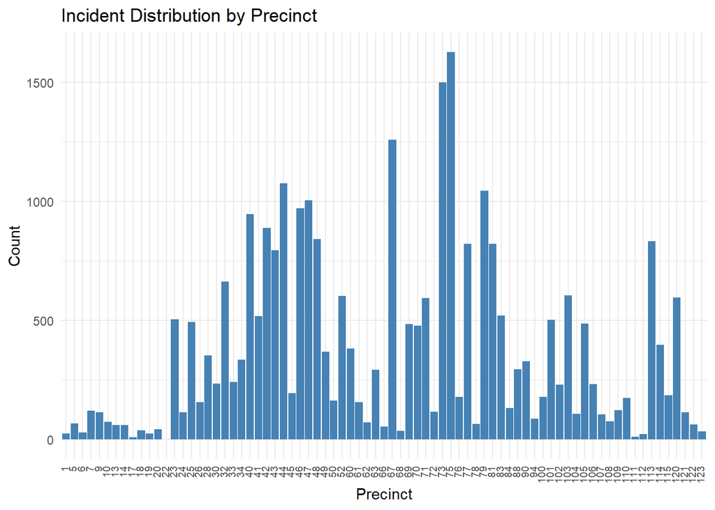

```r
# Create the precinct table
precinct_table <- table(NYPD_data_cleaned$PRECINCT)

# Convert the table to a data frame
precinct_df <- as.data.frame(precinct_table)
colnames(precinct_df) <- c("Precinct", "Count")

# Create the bar chart using ggplot2
ggplot(precinct_df, aes(x = as.factor(Precinct), y = Count)) + geom_bar(stat = "identity",
    fill = "steelblue") + labs(title = "Incident Distribution by Precinct", x = "Precinct",
    y = "Count") + theme_minimal() + theme(axis.text.x = element_text(size = 7, angle = 90,
    hjust = 1, vjust = 0.25))
```

### Distribution by Perpetrator Age Group, Sex, and Race

This section analyzes the distribution of perpetrators by age group, sex, and race.

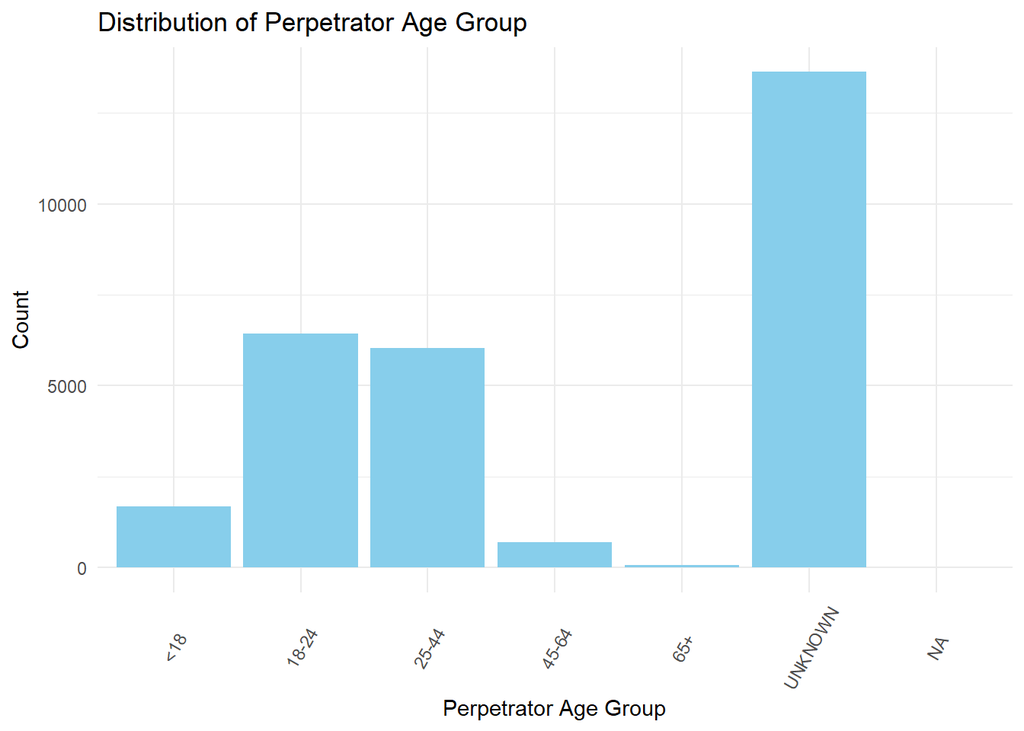

```r
# Plot for PERP_AGE_GROUP
ggplot(NYPD_data_cleaned, aes(x = PERP_AGE_GROUP)) + geom_bar(fill = "skyblue") +
    labs(title = "Distribution of Perpetrator Age Group", x = "Perpetrator Age Group",
        y = "Count") + theme_minimal() + theme(axis.text.x = element_text(angle = 60,
    hjust = 0.5, vjust = 0.5))
```

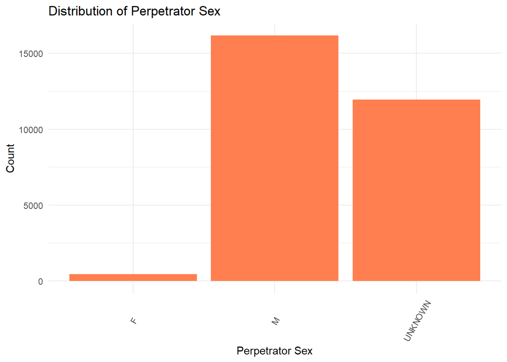

```r
# Plot for PERP_SEX
ggplot(NYPD_data_cleaned, aes(x = PERP_SEX)) + geom_bar(fill = "coral") + labs(title = "Distribution of Perpetrator Sex",
    x = "Perpetrator Sex", y = "Count") + theme_minimal() + theme(axis.text.x = element_text(angle = 60,
    hjust = 0.5, vjust = 0.5))
```

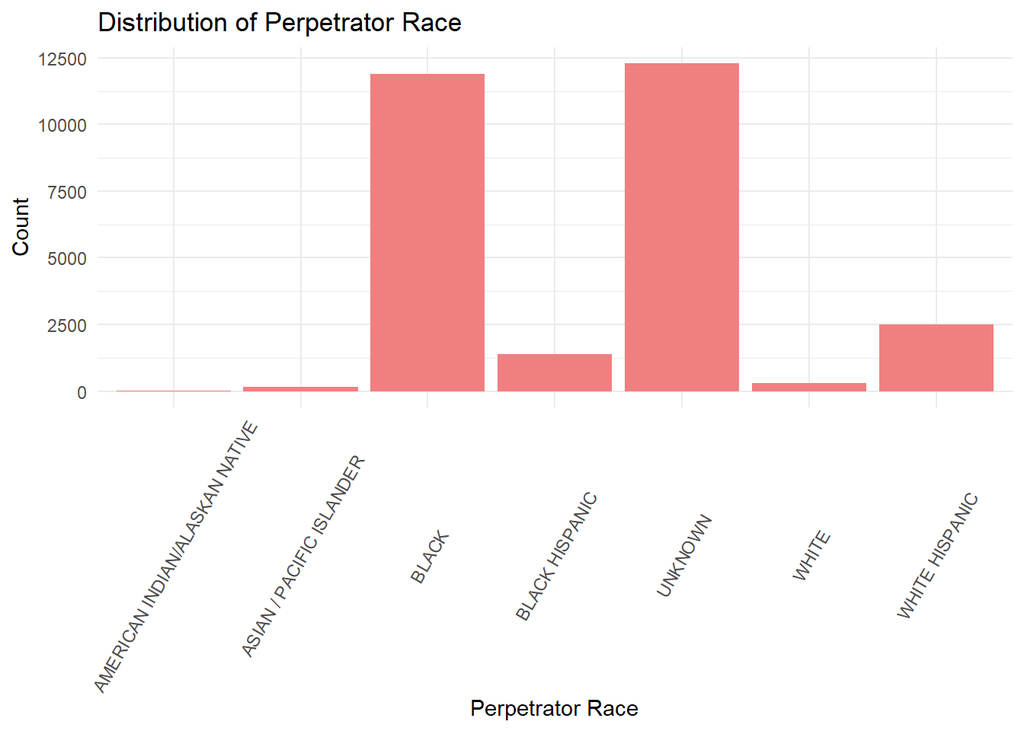

```r
# Plot for PERP_RACE
ggplot(NYPD_data_cleaned, aes(x = PERP_RACE)) + geom_bar(fill = "lightcoral") + labs(title = "Distribution of Perpetrator Race",
    x = "Perpetrator Race", y = "Count") + theme_minimal() + theme(axis.text.x = element_text(angle = 60,
    hjust = 0.5, vjust = 0.5))
```

### Distribution by Victim Age Group, Sex, and Race

This section analyzes the distribution of victims by age group, sex, and race.

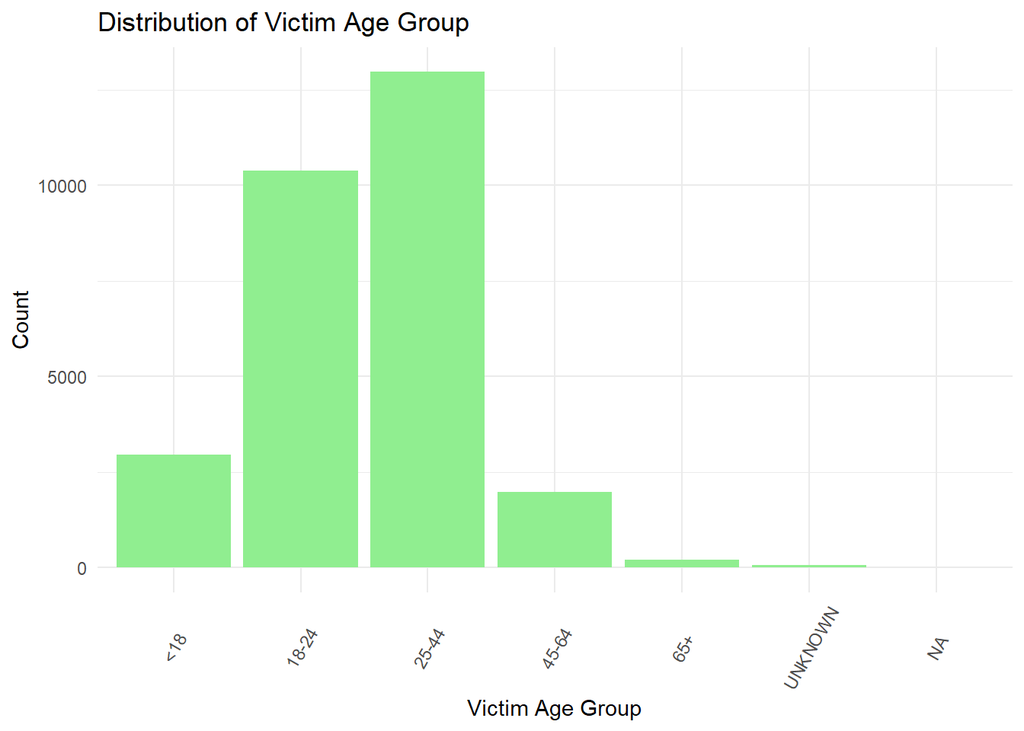

```r
# Plot for VIC_AGE_GROUP
ggplot(NYPD_data_cleaned, aes(x = VIC_AGE_GROUP)) + geom_bar(fill = "lightgreen") +
    labs(title = "Distribution of Victim Age Group", x = "Victim Age Group", y = "Count") +
    theme_minimal() + theme(axis.text.x = element_text(angle = 60, hjust = 0.5, vjust = 0.5))
```

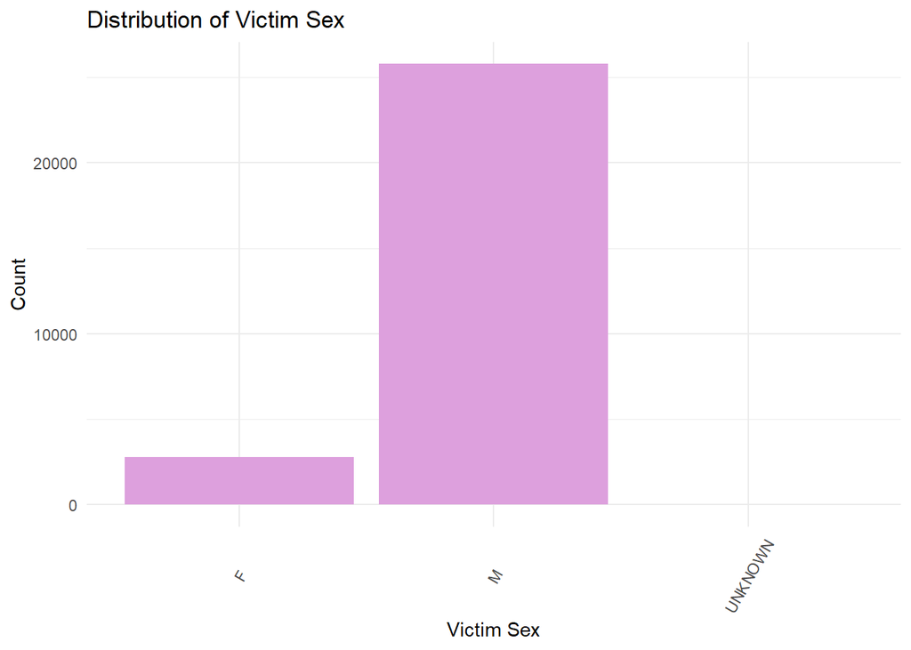

```r
# Plot for VIC_SEX
ggplot(NYPD_data_cleaned, aes(x = VIC_SEX)) + geom_bar(fill = "plum") + labs(title = "Distribution of Victim Sex",
    x = "Victim Sex", y = "Count") + theme_minimal() + theme(axis.text.x = element_text(angle = 60,
    hjust = 0.5, vjust = 0.5))
```

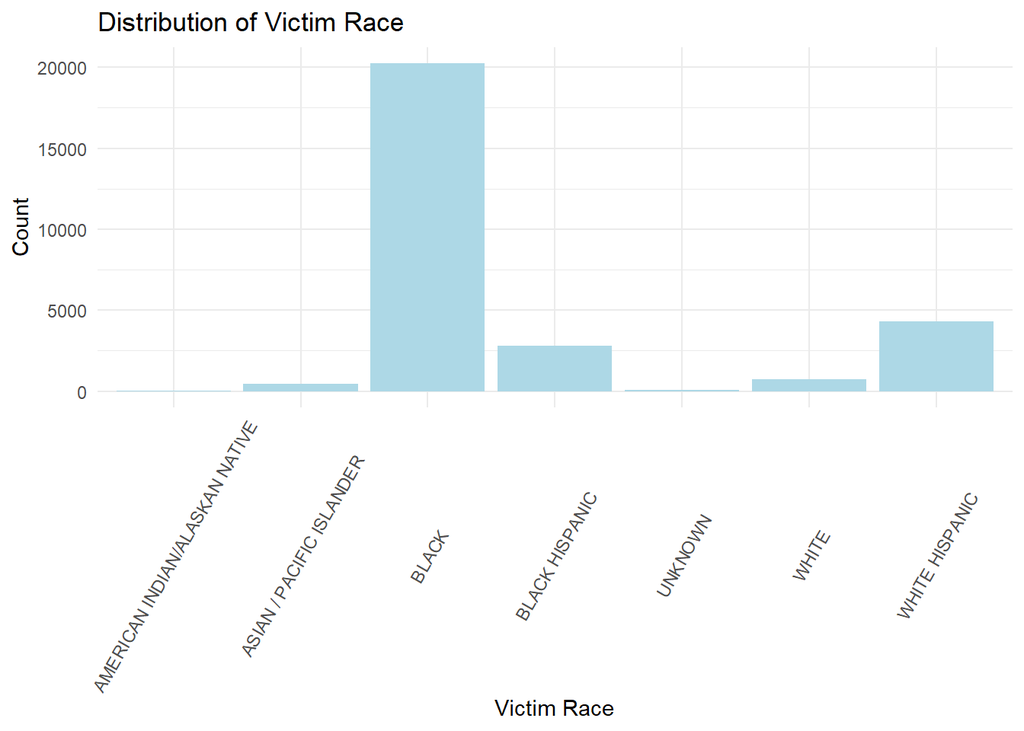

```r
# Plot for VIC_RACE
ggplot(NYPD_data_cleaned, aes(x = VIC_RACE)) + geom_bar(fill = "lightblue") + labs(title = "Distribution of Victim Race",
    x = "Victim Race", y = "Count") + theme_minimal() + theme(axis.text.x = element_text(angle = 60,
    hjust = 0.5, vjust = 0.5))
```

### Contingency Table: Precinct vs. Statistical Murder Flag

This section presents a contingency table showing the relationship between precincts and whether an incident resulted in a murder.

```r
# Convert STATISTICAL_MURDER_FLAG to 0 and 1
NYPD_data_cleaned <- NYPD_data_cleaned %>%
    mutate(STATISTICAL_MURDER_FLAG = ifelse(STATISTICAL_MURDER_FLAG == TRUE, 1, 0))

# Create the contingency table
contingency_table <- table(NYPD_data_cleaned$PRECINCT, NYPD_data_cleaned$STATISTICAL_MURDER_FLAG)

# Convert the table to a data frame
contingency_df <- as.data.frame.matrix(contingency_table)

# Rename the column names
colnames(contingency_df) <- c("Non-Murder", "Murder")
contingency_df <- tibble::rownames_to_column(contingency_df, "Precinct")

# Display the contingency table
kable(contingency_df, col.names = c("Precinct", "Non-Murder", "Murder"), caption = "Precinct vs. Statistical Murder Flag: Shooting resulted in the victim’s death which would be counted as a murder.") %>%
    kable_styling(bootstrap_options = c("striped", "hover", "condensed", "responsive")) %>%
    column_spec(3) %>%
    scroll_box(height = "450px", width = "100%") %>%
    kable_classic("striped", full_width = F)
```

Precinct vs. Statistical Murder Flag: Shooting resulted in the victim’s death which would be counted as a murder.

| Precinct | Non-Murder | Murder |
| --- | --- | --- |
| 1 | 18 | 7 |
| 5 | 50 | 17 |
| 6 | 22 | 6 |
| 7 | 110 | 10 |
| 9 | 89 | 25 |
| 10 | 57 | 17 |
| 13 | 45 | 16 |
| 14 | 45 | 16 |
| 17 | 8 | 2 |
| 18 | 32 | 6 |
| 19 | 18 | 6 |
| 20 | 37 | 6 |
| 22 | 1 | 0 |
| 23 | 423 | 82 |
| 24 | 86 | 27 |
| 25 | 409 | 85 |
| 26 | 138 | 19 |
| 28 | 294 | 59 |
| 30 | 189 | 45 |
| 32 | 540 | 123 |
| 33 | 198 | 44 |
| 34 | 281 | 54 |
| 40 | 783 | 164 |
| 41 | 420 | 99 |
| 42 | 715 | 175 |
| 43 | 653 | 143 |
| 44 | 876 | 200 |
| 45 | 158 | 37 |
| 46 | 772 | 200 |
| 47 | 785 | 221 |
| 48 | 676 | 165 |
| 49 | 284 | 84 |
| 50 | 130 | 32 |
| 52 | 490 | 114 |
| 60 | 303 | 80 |
| 61 | 114 | 43 |
| 62 | 53 | 19 |
| 63 | 236 | 56 |
| 66 | 45 | 8 |
| 67 | 1009 | 250 |
| 68 | 30 | 6 |
| 69 | 393 | 91 |
| 70 | 371 | 108 |
| 71 | 498 | 97 |
| 72 | 92 | 25 |
| 73 | 1223 | 277 |
| 75 | 1299 | 329 |
| 76 | 146 | 33 |
| 77 | 645 | 176 |
| 78 | 57 | 8 |
| 79 | 849 | 196 |
| 81 | 665 | 156 |
| 83 | 424 | 96 |
| 84 | 111 | 20 |
| 88 | 232 | 62 |
| 90 | 266 | 62 |
| 94 | 75 | 12 |
| 100 | 161 | 17 |
| 101 | 414 | 88 |
| 102 | 176 | 53 |
| 103 | 505 | 100 |
| 104 | 87 | 21 |
| 105 | 383 | 105 |
| 106 | 161 | 72 |
| 107 | 82 | 23 |
| 108 | 66 | 9 |
| 109 | 91 | 32 |
| 110 | 135 | 39 |
| 111 | 12 | 0 |
| 112 | 15 | 8 |
| 113 | 673 | 161 |
| 114 | 326 | 71 |
| 115 | 144 | 41 |
| 120 | 481 | 116 |
| 121 | 93 | 21 |
| 122 | 38 | 25 |
| 123 | 25 | 8 |

### Chi-Squared Test: Precinct vs. Statistical Murder Flag

The following code performs a chi-squared test to evaluate the relationship between precincts and whether an incident resulted in a murder.

```r
# Create a chi-squared test for the contingency table
chisq_result <- chisq.test(contingency_table)
chisq_summary <- data.frame(Statistic = chisq_result$statistic, Parameter = chisq_result$parameter,
    P.Value = chisq_result$p.value)
kable(chisq_summary, caption = "Chi-Squared Test Result: Precinct vs. Statistical Murder Flag") %>%
    kable_styling(bootstrap_options = c("striped", "hover", "condensed", "responsive"))
```

Chi-Squared Test Result: Precinct vs. Statistical Murder Flag

|  | Statistic | Parameter | P.Value |
| --- | --- | --- | --- |
| X-squared | 145.8652 | 76 | 2.6e-06 |

### Seasonality of Shooting Incidents

This section examines the seasonality of shooting incidents by plotting the number of incidents per month.

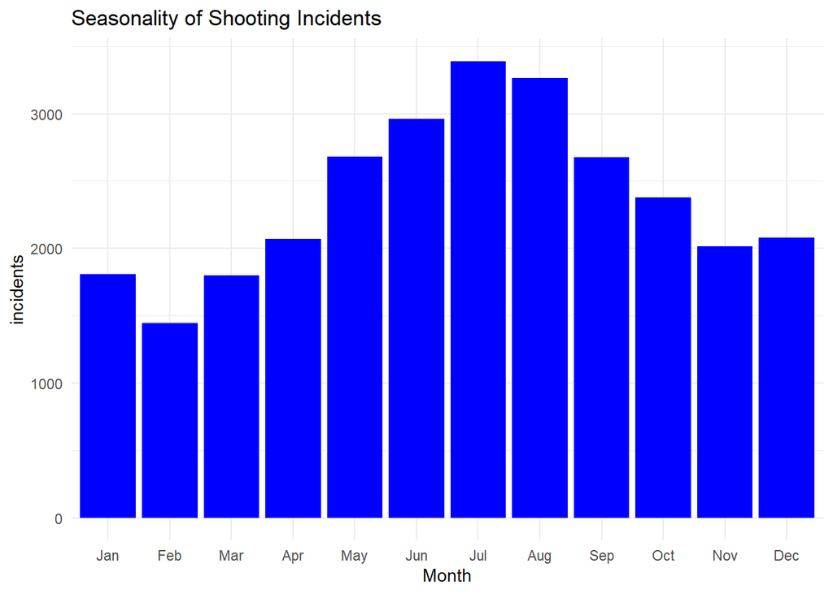

```r
# Convert OCCUR_DATE to Date type if it is not already
NYPD_data_cleaned$OCCUR_DATE <- as.Date(NYPD_data_cleaned$OCCUR_DATE, format = "%m/%d/%Y")

# Extract Month, Day, and Year
NYPD_data_cleaned <- NYPD_data_cleaned %>%
  mutate(
    Month = month(OCCUR_DATE, label = TRUE), # Extract month as labeled factor
    Day = day(OCCUR_DATE),                   # Extract day
    Year = year(OCCUR_DATE)                  # Extract year
  )

# Seasonality
NYPD_data_cleaned %>%
  group_by(Month) %>%
  summarise(incidents = n()) %>%
  ggplot(aes(x = Month, y = incidents)) +
  geom_bar(stat = "identity", fill = "blue") +
  labs(title = "Seasonality of Shooting Incidents") +
  theme_minimal()
```

### Clustering Analysis: NYPD Shooting Clusters

This section performs k-means clustering on the latitude and longitude coordinates of the shooting incidents to identify clusters.

```r
# Remove rows with NA in Latitude or Longitude for clustering
data_no_na <- NYPD_data_cleaned %>%
    filter(!is.na(Latitude) & !is.na(Longitude))

# Precinct count
total_precincts <- NYPD_data_cleaned %>%
    summarise(total_precincts = n_distinct(PRECINCT)) %>%
    pull(total_precincts)

# Perform k-means clustering
data_for_clustering <- data_no_na %>%
    select(Latitude, Longitude)
clusters <- kmeans(data_for_clustering, centers = total_precincts)

# Add cluster results back to the original data frame
data_no_na$cluster <- clusters$cluster

# Calculate the count of each cluster
cluster_counts <- data_no_na %>%
    group_by(cluster) %>%
    summarise(count = n()) %>%
    arrange(cluster)  # Ensure numeric order

# Create custom labels for the legend from the sorted cluster_counts
custom_labels <- paste("Cluster", cluster_counts$cluster, ":", cluster_counts$count)

# Define a custom color palette using viridis
custom_colors <- colorRampPalette(c("violet", "darkblue"))(total_precincts)
color_palette <- colorFactor(palette = custom_colors, domain = data_no_na$cluster)

# Create the interactive map with a custom HTML legend
leaflet(data_no_na) %>%
    addTiles() %>%
    addCircleMarkers(~Longitude, ~Latitude, color = ~color_palette(cluster), radius = 3,
        popup = ~paste("Cluster:", cluster)) %>%
    addControl(html = htmltools::tags$div(style = "max-height: 400px; overflow-y: auto; padding: 10px; background: linear-gradient(to bottom, white, lightblue); opacity: 1;",
        htmltools::tags$h4("Cluster Counts"), htmltools::tags$ul(style = "list-style: none; padding: 0;",
            lapply(seq_along(custom_labels), function(i) {
                htmltools::tags$li(style = paste("color:", custom_colors[i], ";"),
                  custom_labels[i])
            }))), position = "bottomright")
```

[interactive chart not shown]

### Temporal Analysis by Year

Analyze trends over multiple years to understand long-term changes in shooting incidents.

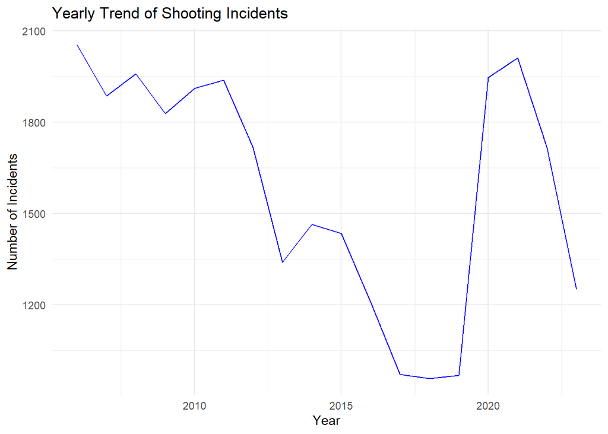

```r
# Group by Year and plot the yearly trend of shooting incidents
NYPD_data_cleaned %>%
    group_by(Year) %>%
    summarise(incidents = n()) %>%
    ggplot(aes(x = Year, y = incidents)) + geom_line(color = "blue") + labs(title = "Yearly Trend of Shooting Incidents",
    x = "Year", y = "Number of Incidents") + theme_minimal()
```

### Predictive Modeling with Logistic Regression

Let’s add an example of how to set up a logistic regression model to predict whether an incident results in a murder.

```r
# Prepare the data
NYPD_data_cleaned_filtered <- NYPD_data_cleaned %>%
    filter(!is.na(STATISTICAL_MURDER_FLAG)) %>%
    mutate(STATISTICAL_MURDER_FLAG = as.factor(STATISTICAL_MURDER_FLAG))

# Select relevant features and remove rows with NA values
features <- c("PRECINCT", "PERP_AGE_GROUP", "PERP_SEX", "PERP_RACE", "VIC_AGE_GROUP",
    "VIC_SEX", "VIC_RACE", "Latitude", "Longitude", "Month", "Day")
data_model <- NYPD_data_cleaned_filtered %>%
    select(all_of(features), STATISTICAL_MURDER_FLAG) %>%
    drop_na(all_of(features), STATISTICAL_MURDER_FLAG)

# Convert categorical variables to dummy variables
data_matrix <- model.matrix(STATISTICAL_MURDER_FLAG ~ ., data = data_model)[, -1]
target <- data_model$STATISTICAL_MURDER_FLAG

# Split the data into training and test sets
set.seed(123)  # For reproducibility
trainIndex <- createDataPartition(target, p = 0.8, list = FALSE)

# Prepare training and testing datasets
data_train <- data_matrix[trainIndex, ]
data_test <- data_matrix[-trainIndex, ]
target_train <- target[trainIndex]
target_test <- target[-trainIndex]

# Ensure there are no missing values in the training and testing sets
if (any(is.na(data_train)) | any(is.na(data_test))) {
    stop("There are still missing values in the data.")
}

# Train the logistic regression model
model <- glmnet(data_train, target_train, family = "binomial")

# Make predictions
predictions <- predict(model, newx = data_test, type = "response")
predicted_classes <- ifelse(predictions > 0.5, 1, 0)

# Upsample target_test to match the length of predicted_classes if necessary
if (length(predicted_classes) != length(target_test)) {
    target_test_upsampled <- rep(target_test, length.out = length(predicted_classes))
} else {
    target_test_upsampled <- target_test
}

# Ensure both predicted and actual target are factors with the same levels
predicted_classes <- factor(predicted_classes, levels = c(0, 1))
target_test_upsampled <- factor(target_test_upsampled, levels = c(0, 1))

# Create the confusion matrix
conf_matrix <- confusionMatrix(predicted_classes, target_test_upsampled)

# print confusion matrix
print(conf_matrix)
```

```
## Confusion Matrix and Statistics
##
##           Reference
## Prediction      0      1
##          0 266222  63971
##          1    288     61
##
##                Accuracy : 0.8056
##                  95% CI : (0.8042, 0.8069)
##     No Information Rate : 0.8063
##     P-Value [Acc > NIR] : 0.8416
##
##                   Kappa : -2e-04
##
##  Mcnemar's Test P-Value : <2e-16
##
##             Sensitivity : 0.9989194
##             Specificity : 0.0009526
##          Pos Pred Value : 0.8062618
##          Neg Pred Value : 0.1747851
##              Prevalence : 0.8062818
##          Detection Rate : 0.8054105
##    Detection Prevalence : 0.9989442
##       Balanced Accuracy : 0.4999360
##
##        'Positive' Class : 0
##
```

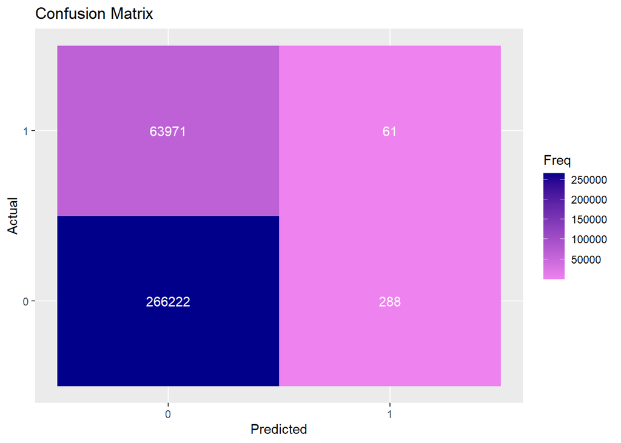

```r
# Convert the confusion matrix to a data frame
conf_matrix_df <- as.data.frame(conf_matrix$table)

# Plot the confusion matrix
ggplot(conf_matrix_df, aes(x = Prediction, y = Reference, fill = Freq)) + geom_tile() +
    geom_text(aes(label = Freq), color = "white") + scale_fill_gradient(low = "violet",
    high = "darkblue") + labs(title = "Confusion Matrix", x = "Predicted", y = "Actual")
```

### Confusion Matrix

The confusion matrix shows the performance of the classification model by comparing the predicted labels to the actual labels. The rows represent the predicted classes, while the columns represent the actual classes.

### Model Performance Metrics

Additional performance metrics for the logistic regression model, such as ROC-AUC, precision, recall, and F1-score, to provide a more comprehensive evaluation.

```r
# Calculate additional performance metrics Ensure the target_test and
# predictions are of the same length
if (length(predictions) != length(target_test_upsampled)) {
    stop("The lengths of predictions and target_test do not match.")
}

# Convert predictions to numeric
numeric_predictions <- as.numeric(predictions)

# Calculate additional performance metrics
roc_auc <- pROC::roc(response = target_test_upsampled, predictor = numeric_predictions)
roc_auc_value <- pROC::auc(roc_auc)

precision <- caret::posPredValue(predicted_classes, target_test_upsampled)
recall <- caret::sensitivity(predicted_classes, target_test_upsampled)
f1_score <- 2 * ((precision * recall)/(precision + recall))

performance_metrics <- data.frame(Metric = c("ROC-AUC", "Precision", "Recall", "F1-Score"),
    Value = c(roc_auc_value, precision, recall, f1_score))

# Display the performance metrics
kable(performance_metrics, caption = "Logistic Regression Performance Metrics") %>%
    kable_styling(bootstrap_options = c("striped", "hover", "condensed", "responsive"))
```

Logistic Regression Performance Metrics

| Metric | Value |
| --- | --- |
| ROC-AUC | 0.6069635 |
| Precision | 0.8062618 |
| Recall | 0.9989194 |
| F1-Score | 0.8923099 |

### Predicted Probability Graph Explanation

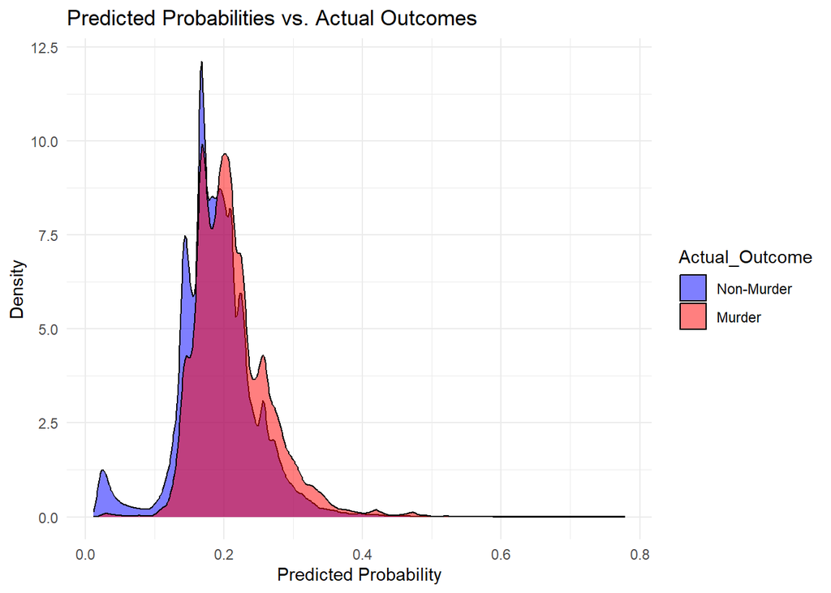

```r
# Create a data frame for plotting predicted probabilities vs actual outcomes
plot_data <- data.frame(Predicted_Probability = as.numeric(predictions), Actual_Outcome = factor(target_test,
    levels = c(0, 1), labels = c("Non-Murder", "Murder")))

# Plot predicted probabilities vs actual outcomes
ggplot(plot_data, aes(x = Predicted_Probability, fill = Actual_Outcome)) + geom_density(alpha = 0.5) +
    labs(title = "Predicted Probabilities vs. Actual Outcomes", x = "Predicted Probability",
        y = "Density") + scale_fill_manual(values = c("blue", "red")) + theme_minimal()
```

### Bias Analysis in NYPD Shooting Incident Data Analysis

When analyzing sensitive data such as the NYPD Shooting Incident Data, it’s crucial to recognize potential biases that may influence the results and interpretations. Here are several key areas where bias could be present in the provided analysis:

#### Selection Bias

The data only includes shooting incidents that were reported and recorded by the NYPD. Incidents that were not reported or recorded accurately are missing, leading to an incomplete picture. Filtering out categories with exactly one occurrence may remove significant but rare events, introducing bias by focusing only on more frequent incidents.

#### Survivorship Bias

Analysis may disproportionately focus on certain precincts or demographics that have higher reporting rates, thereby neglecting areas or groups with lower reporting rates.

#### Reporting Bias

There could be discrepancies in how different precincts or officers report incidents, which may affect the data consistency. For instance, some precincts might be more diligent or have different criteria for reporting.

#### Measurement Bias

The way data is recorded might introduce errors. For example, inaccuracies in recording the exact location, time, or demographics can lead to skewed results. The “STATISTICAL_MURDER_FLAG” relies on accurate determination of whether a shooting resulted in a murder, which might be influenced by subjective judgment or administrative decisions.

#### Sample Size Bias

Removing rows with NA values might lead to a reduced dataset that does not fully represent the original population, especially if NA values are not randomly distributed.

#### Imbalance in Data

The dataset might have an imbalance in the number of incidents across different categories (e.g., more incidents in certain boroughs or involving certain demographics), which can lead to biased model predictions. The confusion matrix indicates a high imbalance between non-murder and murder cases, which affects the model’s ability to accurately predict rare events.

#### Model Bias

Logistic regression and other machine learning models may inherit and amplify existing biases in the data. If the training data is biased, the model predictions will also be biased. The choice of features and how they are encoded (e.g., converting categorical variables to dummy variables) can influence the model’s performance and fairness.

### Suggestions to Address Bias

#### Data Augmentation and Cleaning

Insure thorough cleaning and preprocessing of data to minimize errors and inconsistencies. Consider imputation methods for handling NA values rather than simply removing them. Augment the dataset with additional relevant features that might help reduce bias, such as socioeconomic indicators or historical crime rates.

#### Balanced Sampling

Use techniques like oversampling, undersampling, or synthetic data generation (e.g., SMOTE) to address class imbalances in the dataset.

#### Bias Detection and Mitigation

Implement fairness-aware algorithms and bias detection techniques to identify and mitigate biases in the model. Regularly evaluate the model’s performance across different demographic groups to ensure fairness and equity.

#### Transparency and Documentation

Clearly document the data sources, preprocessing steps, and any assumptions made during the analysis to enhance transparency and reproducibility. Provide contextual information about potential biases and limitations of the analysis to inform stakeholders and decision-makers.

#### Engage with Stakeholders

Collaborate with community stakeholders, law enforcement, and subject matter experts to validate findings and ensure that the analysis considers diverse perspectives and real-world implications.

### Conclusions from the NYPD Shooting Incident Analysis

The NYPD Shooting Incident Analysis provides valuable insights into the distribution, temporal trends, and demographic patterns of shooting incidents in New York City. While the analysis highlights significant patterns and potential areas of intervention, it also underscores the need for continuous improvement in data quality, model performance, and bias mitigation. By addressing these recommendations, the analysis can provide more accurate, fair, and actionable insights to help reduce shooting incidents and improve public safety in New York City.

### Recommendations

- Improve Data Quality: Enhance the accuracy and completeness of the data collection process. Addressing missing values through advanced imputation techniques and ensuring consistent reporting across precincts can improve the reliability of the analysis.
- Enhance Model Performance: Consider using more advanced machine learning models and techniques to improve specificity and overall model performance. Techniques such as ensemble methods or incorporating additional features could help in better distinguishing between non-murder and murder incidents.
- Address Biases: Implement strategies to detect and mitigate biases in the data and model. Regularly evaluate the model’s fairness across different demographic groups and ensure transparency in reporting the analysis.
- Stakeholder Collaboration: Engage with community stakeholders, law enforcement, and experts to validate findings and incorporate diverse perspectives. Collaborative efforts can lead to more effective and equitable interventions.
- Regular Updates and Monitoring: Update the analysis regularly to reflect the most recent data and monitor trends over time. This will help in identifying emerging patterns and making timely adjustments to strategies and policies.